# France on GISAID

FD

2021-07-21

# Initializations

```r
# Colors
library(RColorBrewer)
colsV <- rep(c(brewer.pal(12, "Paired"), brewer.pal(12, "Set3"), brewer.pal(9, "Set1")), 20)
colsP <- brewer.pal(5, "Set1")
names(colsP) <- c("autre", "HCL", "HMN", "IHU", "IPP")
colsC <- c(brewer.pal(9, "Set1"), brewer.pal(6, "Set2"), brewer.pal(12, "Set3"))
colsV2 <- brewer.pal(9, "Set3")

cols <- brewer.pal(n = 3, name = "Dark2")
```

```r
# Function to identify entries that are NA or empty
is.NAempty <- function(x){
  is.na(x) | x == ""
}
```

# Load and clean data

Data source: `metadata.tsv`, downloaded from [GISAID](https://www.gisaid.org).

Then, in console

```
grep "hCoV-19/France" metadata.tsv
```

to extract sequences from France (as country) only. The resulting file is stored in the `data/` folder.

Note: Oversea territories are referenced as independent on GISAID

## Load data

```r
dat <- read.csv("data/2021-07-20_France.tsv", sep = "\t", stringsAsFactors = FALSE, header = FALSE)
head(dat)
names(dat) <- c("Virus.name", "Type", "Accession.ID", "Collection.date", "Location", "Additional.location.information", "Sequence.length", "Host", "Patient.age", "Gender", "Clade", "Pango.lineage", "Pangolin.version", "Variant", "AA.Substitutions", "Submission.date", "Is.reference", "Is.complete", "Is.high.coverage", "Is.low.coverage", "N.Content", "GC.Content")
```

There are 57438 lines in the dataset.

## Clean data

Dates: full date, year-month and year

```r
# Reformat dates

# Table of the lengths of the different dates
table(nchar(dat$Collection.date)) # There are incomplete dates
table(nchar(dat$Submission.date))

# Turn dates into date format, and put NA for incomplete dates
getDate <- function(v){
  out <- v
  # Remove lines with incomplete date information
  out[nchar(out) < 10] <- NA
  base::as.Date(out)
}

dat$Collection.date.YMD <- getDate(dat$Collection.date)
dat$Submission.date.YMD <- getDate(dat$Submission.date)

# Extract month
getYM <- function(v){
  out <- v
  # Remove lines with incomplete date information
  out[nchar(out) < 7] <- NA
  substr(out, 1, 7)
}

dat$Collection.date.YM <- getYM(dat$Collection.date)
dat$Submission.date.YM <- getYM(dat$Submission.date)

# Extract year
getY <- function(v){
  out <- v
  # Remove lines with incomplete date information
  out[nchar(out) < 4] <- NA
  substr(out, 1, 4)
}

dat$Collection.date.Y <- getY(dat$Collection.date)
dat$Submission.date.Y <- getY(dat$Submission.date)
```

Dates: get week numbers  
(currently only done for 2021)

```r
# NOTE: THIS IS ONLY FOR 2021 -- need to change method for 2020, or do it separately

endDay <- max(dat$Submission.date.YMD)
beginDay <- seq(base::as.Date("2021-01-04"), base::as.Date("2021-12-27"), by = 7)
endDay <- seq(base::as.Date("2021-01-10"), base::as.Date("2022-01-02"), by = 7)
weeks <- as.data.frame(cbind(weekBegin = beginDay, weekEnd = endDay, week = 1:52))


# Assign weeks
  # Initialize week numbers
dat$Collection.week <- NA
dat$Submission.week <- NA

for(iw in weeks$week){
  # Collection week
  dat[which(base::as.Date(dat$Collection.date.YMD) >= base::as.Date(weeks[iw, "weekBegin"], origin = "1970-01-01") & base::as.Date(dat$Collection.date.YMD) <= base::as.Date(weeks[iw, "weekEnd"], origin = "1970-01-01")), "Collection.week"] <- iw

  # Submission week
  dat[which(base::as.Date(dat$Submission.date.YMD) >= base::as.Date(weeks[iw, "weekBegin"], origin = "1970-01-01") & base::as.Date(dat$Submission.date.YMD) <= base::as.Date(weeks[iw, "weekEnd"], origin = "1970-01-01")), "Submission.week"] <- iw
}
```

Difference between submission and collection dates

```r
dat$diffSubCol <- as.numeric(dat$Submission.date.YMD - dat$Collection.date.YMD)
```

Locations:  
Try to get some uniformity automatically because some spellings differ

```r
# Extract locations
# Reformat locations:
# 1) Remove spaces
locs <- gsub(" ", "", dat$Location)
# 2) Convert to upper case
locs <- toupper(locs)
# 3) Remove dashes
locs <- gsub("-", "", locs)
locs <- gsub("_", "", locs)
# 4) Remove some accents
#    A
for(char in c("À", "Â", "Ä")){
  locs <- gsub(char, "A", locs)
}
#    E
for(char in c("È", "É", "Ê")){
  locs <- gsub(char, "E", locs)
}
#    I
for(char in c("Î")){
  locs <- gsub(char, "I", locs)
}
#    O
for(char in c("Ô")){
  locs <- gsub(char, "O", locs)
}

# Split locations
# Locations are presented as a single string, which we split
locs <- strsplit(locs, "/")
# The strings are of different lengths / precision; get length (number of geographic divisions)
lenlocs <- sapply(locs, length)
table(lenlocs)
# Turn into matrix, filling with NAs
# Source: https://stackoverflow.com/a/15201690
mat <- as.data.frame(t(sapply(locs, "[", i = 1:max(lenlocs))))
names(mat) <- c("continent", "country", "region", "div4", "div5")
dat <- cbind(dat, mat)
# Also add information about location precision
dat <- cbind(dat, locationLength = lenlocs)
names(dat)
```

Hosts

```r
# Uniformize notation
dat[dat$Host == "human", "Host"] <- "Human"
```

## Flash

Load Flash dates

```r
datesFlash <- read.csv("../gisaid_covid/data/datesFlash.csv", stringsAsFactors = FALSE, header = FALSE)
names(datesFlash) <- c("FlashNb", "date", "date2", "week")
datesFlash.all <- datesFlash
# Remove Flash 1 and 2, which were not on a random sample
datesFlash <- datesFlash[datesFlash$FlashNb >=3 , ]
```

# France

```r
table(country = dat$country)
```

```
## country
##     FRANCE GUADELOUPE
##      57419         19
```

```r
# Keep only mainland France
dat <- dat[dat$country == "FRANCE", ]
```

There are 57419 samples with location in France.

Get submitter information from Virus name

```r
ipp <- grep(dat$Virus.name, pattern = "IPP")
hcl <- grep(dat$Virus.name, pattern = "HCL")
ihu <- grep(dat$Virus.name, pattern = "IHU")
hmn <- grep(dat$Virus.name, pattern = "HMN")


dat$submitter <- rep("autre", nrow(dat))
dat[ipp, "submitter"] <- "IPP"
dat[hcl, "submitter"] <- "HCL"
dat[ihu, "submitter"] <- "IHU"
dat[hmn, "submitter"] <- "HMN"

table(dat$submitter, useNA = "ifany")
```

```
##
## autre   HCL   HMN   IHU   IPP
## 17666 10795  9255 10467  9236
```

```r
submitters <- sort(unique(dat$submitter))
```

### Sequence metadata

Dates

- The fraction of samples with missing full day of collection is 0.19

Distribution of samples with incomplete collection date information, by submitter

```r
totSeq <- table(dat$submitter)
tt <- table(dat[which(is.na(dat$Collection.date.YMD)), "submitter"])

rbind(incomplete_collectionDate = tt, tot_seq = totSeq[names(tt)])
```

```
##                           autre   IHU  IPP
## incomplete_collectionDate  3908  6672  292
## tot_seq                   17666 10467 9236
```

Location

- The fraction of samples with missing regional information is 0.03

Distribution of entries with incomplete location, by submitter

```r
tt <- table(dat[which(is.na(dat$region)), "submitter"])

rbind(missing_region = tt, tot_seq = totSeq[names(tt)])
```

```
##                autre  HMN
## missing_region   821  749
## tot_seq        17666 9255
```

Regions need to be standardized…

```r
sort(unique(dat$region))
```

```
##  [1] "ALPESMARITIMES"          "ALSACE"
##  [3] "AQUITAINE"               "ARIEGE"
##  [5] "AUDE"                    "AUVERGNE"
##  [7] "AUVERGNERHONEALPES"      "AVEYRON"
##  [9] "BASSENORMANDIE"          "BOURGOGNE"
## [11] "BOURGOGNEFRANCHECOMTE"   "BRETAGNE"
## [13] "CENTRE"                  "CENTREVALDELOIRE"
## [15] "CHAMPAGNEARDENNE"        "CORSE"
## [17] "COTED'AZUR"              "GERS"
## [19] "GRANDEST"                "GRENOBLE"
## [21] "GUYANE"                  "HAUTEGARONNE"
## [23] "HAUTENORMANDIE"          "HAUTESPYRENEES"
## [25] "HAUTRHIN"                "HAUTSDEFRANCE"
## [27] "ILEDEFRANCE"             "LORRAINE"
## [29] "LOT"                     "LOTETGARONNE"
## [31] "MARSEILLE"               "MEUSE"
## [33] "NICE"                    "NORDPASDECALAIS"
## [35] "NORMANDIE"               "NORMANDY"
## [37] "NOUVELLEAQUITAINE"       "OCCITANIE"
## [39] "PAC"                     "PAYSDELALOIRE"
## [41] "PAYSDELOIRE"             "PICARDIE"
## [43] "POITOUCHARENTES"         "PROVENCEALPESCOTEAZUR"
## [45] "PROVENCEALPESCOTED'AZUR" "PYRENEESORIENTALES"
## [47] "RHONEALPES"              "TARN"
## [49] "TARNETGARONNE"           "VALD'OISE"
```

### Metadata on hosts

```r
# Hosts
table(dat$Host)
```

```
##
## Human
## 57419
```

Age

```r
# Age
dat[which(is.element(dat$Patient.age, c("unknown", "Unknown"))), "Patient.age"] <- NA

# Convert to numeric values
# if contains characters -> NA
dat$Patient.age <- suppressWarnings(as.numeric(dat$Patient.age))
```

The fraction of samples with missing or incorrect age information is 0.3.

Missing age by submitter

```r
tt <- table(dat[which(is.na(dat$Patient.age)), "submitter"])
rbind(missing_age = tt, tot_seq = totSeq[names(tt)])
```

```
##             autre   HCL  HMN   IHU  IPP
## missing_age  5524   842  125 10467  554
## tot_seq     17666 10795 9255 10467 9236
```

Distribution of ages

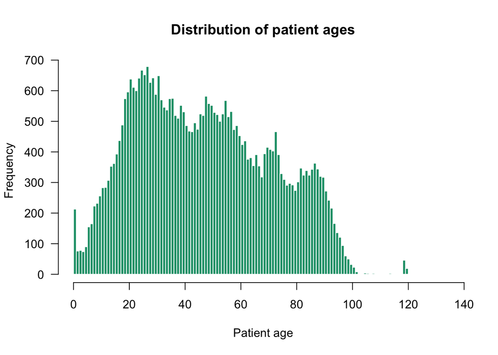

```r
par(las = 1)
hist(dat$Patient.age, xlab = "Patient age", main = "Distribution of patient ages", breaks = seq(0, max(dat$Patient.age, na.rm = TRUE), by = 1), border = gray(1, 1), col = cols[1])
```

“Gender” information

```r
unique(dat$Gender)
# Clean
dat[which(is.element(dat$Gender, c("unknown", "Unknown", "Femal", "Maleale"))), "Gender"] <- NA

table(dat$Gender, useNA = "ifany")
```

```r
# Distribution by submitter
rbind(missing_age = table(dat[which(is.na(dat$Gender)), "submitter"]), tot_seq = table(dat$submitter))
```

```
##             autre   HCL  HMN   IHU  IPP
## missing_age  4445   284  346 10465 2156
## tot_seq     17666 10795 9255 10467 9236
```

### Virus

```r
# "Clade"                           "Pango.lineage"
# "Pangolin.version"                "Variant"
# "AA.Substitutions"
```

Clades

```r
table(dat$Clade, useNA = "ifany")
```

```
##
##     G    GH    GR   GRY    GV     L     O     S     V
##  9951 11346  4085 28694  1802    34   889   573    45
```

Pango lineage info is missing in a fraction 0 of items.

Pangolin version

```r
table(dat$Pangolin.version)
```

```
##
## 2021-07-09
##      57419
```

## Submissions

### By Platform

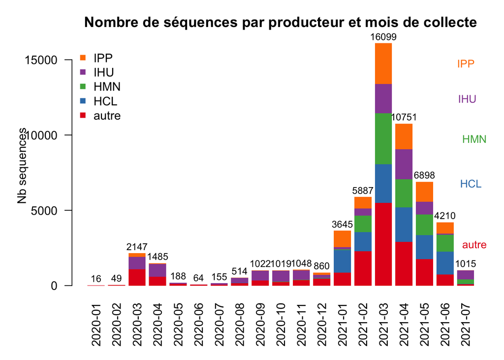

```r
tabFRsub <- aggregate(dat$Virus.name, by = list(subID = dat$submitter, subM = dat$Collection.date.YM), FUN = length)

tabFRsub.month <- aggregate(dat$Virus.name, by = list(subM = dat$Collection.date.YM), FUN = length)


par(mgp = c(3, 1, 0))
par(mar = c(5, 5, 3, 1))
x <- barplot(tabFRsub$x ~ tabFRsub$subID + tabFRsub$subM, col = colsP[1:(length(unique(tabFRsub$subID)))], border = gray(0, 0),
             xlab = "", ylab = "Nb sequences", las = 2,
             main = "Nombre de séquences par producteur et mois de collecte")

z <- tabFRsub[tabFRsub$subM == "2021-03", ]
text(x = rep(x[length(x)-1], 5), y = cumsum(z$x) - z$x/2, labels = z$subID, adj = c(-0.7, 0.5), col = colsP, cex = 0.9) # pos 4 for left-justified
par(xpd = TRUE)
text(x = x, y = tabFRsub.month$x, labels = tabFRsub.month$x, cex = 0.8, adj = c(0.5, -0.5))
legend("topleft", col = rev(colsP), legend = rev(names(colsP)), pch = 15, bty = "n")
```

```r
par(xpd = FALSE)
```

By platform, by week

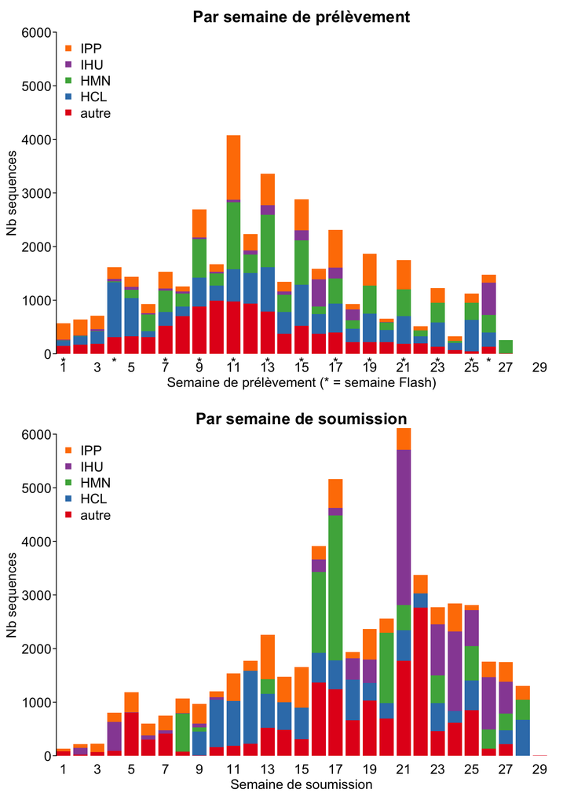

```r
# By collection week
tabFRsub.byweek <- aggregate(dat$Virus.name, by = list(subID = dat$submitter, subweek = dat$Collection.week), FUN = length)
names(tabFRsub.byweek)[3] <- "byCollectionDate"

tabFRsubS.byweek <- aggregate(dat$Virus.name, by = list(subID = dat$submitter, subweek = dat$Submission.week), FUN = length)
names(tabFRsubS.byweek)[3] <- "bySubmissionDate"

seq.byWeek <- merge(tabFRsub.byweek, tabFRsubS.byweek, all = TRUE)
ymax <- 6000

seq.byWeek[is.na(seq.byWeek$byCollectionDate), "byCollectionDate"] <- 0
seq.byWeek[is.na(seq.byWeek$bySubmissionDate), "bySubmissionDate"] <- 0

par(mfrow = c(2, 1))
themar <- c(3, 3.5, 2, 1)
thetck <- -0.01
themgp <- c(2.3, 0.3, 0)
par(mar = themar, mgp = themgp, tck = thetck)

x <- barplot(seq.byWeek$byCollectionDate ~ seq.byWeek$subID + seq.byWeek$subweek, col = colsP[1:(length(unique(tabFRsub$subID)))], border = gray(0, 0),
             xlab = "", ylab = "Nb sequences", las = 1,
             main = "Par semaine de prélèvement", xaxs = "i", yaxs = "i", ylim = c(0, ymax))
legend("topleft", col = rev(colsP), legend = rev(names(colsP)), pch = 15, bty = "n")

stopifnot(length(x) == length(unique(seq.byWeek$subweek))) # Make sure that lengths match

xw <- data.frame(cbind(x = x, week = unique(seq.byWeek$subweek)))
ii <- is.element(xw$week, datesFlash.all$week)
par(xpd = TRUE)
text(labels = "*", x = xw[ii, "x"], y = rep(-100, length(xw[ii, "x"])))
par(xpd = FALSE)
mtext("Semaine de prélèvement (* = semaine Flash)", side = 1, line = 1.25)


par(mar = themar, mgp = themgp, tck = thetck)
x2 <- barplot(seq.byWeek$bySubmissionDate ~ seq.byWeek$subID + seq.byWeek$subweek, col = colsP[1:(length(unique(seq.byWeek$subID)))], border = gray(0, 0),
             xlab = "", ylab = "Nb sequences", las = 1,
             main = "Par semaine de soumission", xaxs = "i", yaxs = "i", ylim = c(0, ymax))
legend("topleft", col = rev(colsP), legend = rev(names(colsP)), pch = 15, bty = "n")
mtext("Semaine de soumission", side = 1, line = 1.25)
```

## Lineages over time

### Variants

Use short names

```r
dat$VariantShort <- dat$Variant

variants <- sort(unique(dat$Variant))
# variants
variantsShort <- c("", "Alpha", "Beta", "Delta", "Gamma", "Epsilon", "Eta", "Iota", "Kappa", "Lambda", "Zeta")
# Check
rbind(variants, variantsShort)
```

```
##               [,1] [,2]
## variants      ""   "VOC Alpha 202012/01 GRY (B.1.1.7) first detected in the UK"
## variantsShort ""   "Alpha"
##               [,3]
## variants      "VOC Beta GH/501Y.V2 (B.1.351) first detected in South Africa"
## variantsShort "Beta"
##               [,4]
## variants      "VOC Delta G/478K.V1 (B.1.617.2+AY.1+AY.2) first detected in India"
## variantsShort "Delta"
##               [,5]
## variants      "VOC Gamma GR/501Y.V3 (P.1) first detected in Brazil/Japan"
## variantsShort "Gamma"
##               [,6]
## variants      "VOI Epsilon GH/452R.V1 (B.1.429+B.1.427) first detected in USA/California"
## variantsShort "Epsilon"
##               [,7]
## variants      "VOI Eta G/484K.V3 (B.1.525) first detected in UK/Nigeria"
## variantsShort "Eta"
##               [,8]
## variants      "VOI Iota GH/253G.V1 (B.1.526) first detected in USA/New York"
## variantsShort "Iota"
##               [,9]
## variants      "VOI Kappa G/452R.V3 (B.1.617.1) first detected in India"
## variantsShort "Kappa"
##               [,10]
## variants      "VOI Lambda GR/452Q.V1 (C.37) first detected in Peru"
## variantsShort "Lambda"
##               [,11]
## variants      "VOI Zeta GR/484K.V2 (P.2) first detected in Brazil"
## variantsShort "Zeta"
```

```r
# Assign shorter name
for(i in seq_along(variants)){
  dat[which(dat$Variant == variants[i]), "VariantShort"] <- variantsShort[i]
}
```

Load TESSy

```r
dlData <- FALSE # Whether to download the data again from the ECDC website
source("TESSy.R")
```

### Beta

```r
tessy.Beta <- (dat.tessy.FR$variant == "B.1.351")
tmp <- dat.tessy.FR[tessy.Beta, ]

# Aggregate the data by week of collection
tmp.nBeta <- aggregate(tmp$number_detections_variant, by = list(week = tmp$week), FUN = sum)
# Number of sequences that week
tmp.n <- aggregate(dat.tessy.FR$number_detections_variant, by = list(week = dat.tessy.FR$week), FUN = sum, na.rm = TRUE)
# Merge and name
tessyBeta.byweek <- merge(tmp.nBeta, tmp.n, by = "week")
names(tessyBeta.byweek) <- c("week", "nBeta", "n")
tessyBeta.byweek$p <- tessyBeta.byweek$nBeta / tessyBeta.byweek$n
# Confidence interval for proportion
tessyBeta.byweek$deltaCI <- with(tessyBeta.byweek, 1.96 * sqrt(p * (1-p)/n))
```

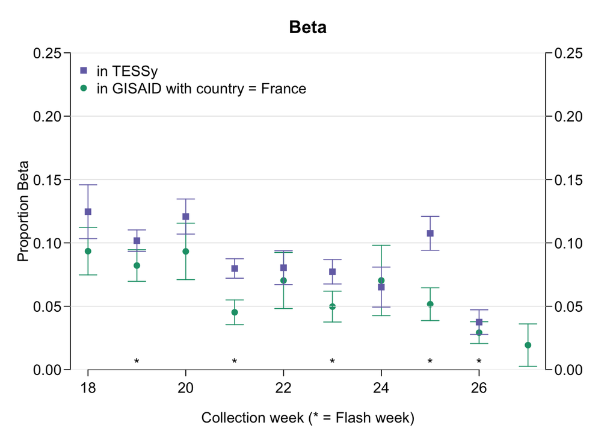

```r
par(mfrow = c(1,1))
is.Beta <- dat$VariantShort == "Beta"

# Aggregate the data by week of collection
tmp.mean <- aggregate(is.Beta, by = list(week = dat$Collection.week), FUN = mean)
# Number of sequences that week
tmp.n <- aggregate(is.Beta, by = list(week = dat$Collection.week), FUN = length)
# Merge and name
Beta.byweek <- merge(tmp.mean, tmp.n, by = "week")
names(Beta.byweek) <- c("week", "p", "n")
# Confidence interval for proportion
Beta.byweek$deltaCI <- with(Beta.byweek, 1.96 * sqrt(p * (1-p)/n))

par(las = 1, mar = c(4, 4, 3, 4),
    mgp = c(2.2, 0.5, 0), tck = -0.02,
    xpd = FALSE)
plot(Beta.byweek$week, Beta.byweek$p, xlim = c(19, max(Beta.byweek$week)) + c(-1, 0),
     xlab = "Collection week (* = Flash week)", ylab = "Proportion Beta", ylim = c(0, 0.25),
     frame.plot = FALSE, yaxs = "i", col = cols[1], pch = 16, main = "Beta")
axis(4)

for(i in seq(0, 1, by = 0.05)) abline(h = i, col = gray(0.9))

arrows(x0 = Beta.byweek$week, y0 = Beta.byweek$p + Beta.byweek$deltaCI,
       x1 = Beta.byweek$week, y1 = Beta.byweek$p - Beta.byweek$deltaCI,
       code = 3, angle = 90, length = 0.1, col = cols[1])

points(tessyBeta.byweek$week, tessyBeta.byweek$p, col = cols[3], pch = 15)

arrows(x0 = as.numeric(tessyBeta.byweek$week), y0 = tessyBeta.byweek$p + tessyBeta.byweek$deltaCI,
       x1 = as.numeric(tessyBeta.byweek$week), y1 = tessyBeta.byweek$p - tessyBeta.byweek$deltaCI,
       code = 3, angle = 90, length = 0.1, col = cols[3])

par(xpd = TRUE)
text(datesFlash[datesFlash$week >=18, "week"], 0.0075, "*")

legend("topleft", col = rev(cols[c(1, 3)]), legend = rev(c("in GISAID with country = France", "in TESSy")), pch = rev(c(16, 15)), bty = "n")
```

There are 2149 Beta sequences.

### Load other data

Load screening data (criblage)

```r
source("publicData_criblage.R")
```

### AA changes

```r
# Extract AA
tmp <- gsub('\\(', '', dat$AA.Substitutions)
tmp <- gsub('\\)', '', tmp)
aa <- strsplit(tmp, ",")
```

#### L452R

```r
# Extract information on whether the S:L452R is present as aa substitution in the sequence
i.L452R <- sapply(aa, function(x){(is.element("Spike_L452R", x))})
```

Overall, fraction of all sequences with the L452R mutation: 0.0447935.

```r
# Aggregate the data by week of collection
# Proportion of sequences with L452R that week
tmp.mean <- aggregate(i.L452R, by = list(week = dat$Collection.week), FUN = mean)
# Number of sequences that week
tmp.n <- aggregate(i.L452R, by = list(week = dat$Collection.week), FUN = length)
# Merge and name
L452R.byweek <- merge(tmp.mean, tmp.n, by = "week")
names(L452R.byweek) <- c("week", "p", "n")
# Confidence interval for proportion
L452R.byweek$deltaCI <- with(L452R.byweek, 1.96 * sqrt(p * (1-p)/n))
```

Which variant harbor the L452R mutation?

```r
table(dat[which(dat$Collection.week >= 21 & i.L452R), "VariantShort"])
```

```
##
##           Alpha   Delta Epsilon   Kappa
##      72      10    1661       2       1
```

```r
dat.France$deltaCI_C1 <- 1.96 * sqrt(dat.France$tx_C1/100 * (1-dat.France$tx_C1/100) / (dat.France$nb_C1 + dat.France$nb_C0))
```

[figure not shown]

```r
par(las = 1, mar = c(4, 4, 3, 4),
    mgp = c(2., 0.5, 0), tck = -0.02,
    xpd = FALSE)
plot(L452R.byweek$week, L452R.byweek$p, xlim = range(dat.France$week, na.rm = TRUE) + c(-1, 0),
     xlab = "Collection week", ylab = "Proportion L452R", ylim = c(0, 1),
     frame.plot = FALSE, yaxs = "i", col = cols[1], pch = 16, main = "L452R")
axis(4)

for(i in seq(0, 1, by = 0.1)) abline(h = i, col = gray(0.9))

arrows(x0 = L452R.byweek$week, y0 = L452R.byweek$p + L452R.byweek$deltaCI,
       x1 = L452R.byweek$week, y1 = L452R.byweek$p - L452R.byweek$deltaCI,
       code = 3, angle = 90, length = 0.1, col = cols[1])

points(dat.France$week, dat.France$tx_C1/100, col = cols[2], pch = 16)

arrows(x0 = dat.France$week, y0 = dat.France$tx_C1/100 + dat.France$deltaCI_C1,
       x1 = dat.France$week, y1 = dat.France$tx_C1/100 - dat.France$deltaCI_C1,
       code = 3, angle = 90, length = 0.1, col = cols[2])

legend("topleft", col = cols[1:2], legend = c("Parmi les séquences sur GISAID", "Données de criblage"), pch = 16, bty = "n")

par(xpd = TRUE)
text(datesFlash[which(datesFlash$week >= min(dat.France$week, na.rm = TRUE) -1), "week"], -0.125, "*")
```

Que se passe-t-il en semaine 24-25 ? Nombres de sequences par regions

```r
tmp25 <- dat[which(i.L452R & dat$Collection.week == 25), ]
table(tmp25$region)
```

```
##
##      AUVERGNERHONEALPES   BOURGOGNEFRANCHECOMTE                BRETAGNE
##                     196                      38                       2
##        CENTREVALDELOIRE                GRANDEST           HAUTSDEFRANCE
##                      22                      36                       4
##             ILEDEFRANCE               NORMANDIE       NOUVELLEAQUITAINE
##                     133                       3                      66
##               OCCITANIE           PAYSDELALOIRE             PAYSDELOIRE
##                      26                       3                       2
## PROVENCEALPESCOTED'AZUR
##                      13
```

```r
tmp24 <- dat[which(i.L452R & dat$Collection.week == 24), ]
table(tmp24$region)
```

```
##
##      AUVERGNERHONEALPES   BOURGOGNEFRANCHECOMTE        CENTREVALDELOIRE
##                      33                       4                       5
##                GRANDEST           HAUTSDEFRANCE             ILEDEFRANCE
##                       6                      12                      43
##       NOUVELLEAQUITAINE               OCCITANIE           PAYSDELALOIRE
##                      14                       5                       5
## PROVENCEALPESCOTED'AZUR
##                       2
```

#### E484K

```r
# Extract information on whether the S:E484K is present as aa substitution in the sequence
i.E484K <- sapply(aa, function(x){(is.element("Spike_E484K", x))})
mean(i.E484K)
```

```
## [1] 0.08645222
```

```r
# Aggregate the data by week of collection
# Proportion of sequences with L452R that week
tmp.mean <- aggregate(i.E484K, by = list(week = dat$Collection.week), FUN = mean)
# Number of sequences that week
tmp.n <- aggregate(i.E484K, by = list(week = dat$Collection.week), FUN = length)
# Merge and name
E484K.byweek <- merge(tmp.mean, tmp.n, by = "week")
names(E484K.byweek) <- c("week", "p", "n")
# Confidence interval for proportion
E484K.byweek$deltaCI <- with(E484K.byweek, 1.96 * sqrt(p * (1-p)/n))
```

```r
table(dat[which(dat$Collection.week >= 21 & i.E484K), "VariantShort"])
```

```
##
##       Alpha  Beta Delta   Eta Gamma  Iota
##   198   147   251     1    68   151     1
```

```r
dat.France$deltaCI_A1 <- 1.96 * sqrt(dat.France$tx_A1/100 * (1-dat.France$tx_A1/100) / (dat.France$nb_A1 + dat.France$nb_A0))
```

[figure not shown]

```r
par(las = 1, mar = c(4, 4, 3, 4),
    mgp = c(2., 0.5, 0), tck = -0.02,
    xpd = FALSE)
plot(E484K.byweek$week, E484K.byweek$p, xlim = range(dat.France$week, na.rm = TRUE) + c(-1, 0),
     xlab = "Collection week", ylab = "Proportion E484K", ylim = c(0, 1),
     frame.plot = FALSE, yaxs = "i", col = cols[1], pch = 16, main = "E484K")
axis(4)

for(i in seq(0, 1, by = 0.1)) abline(h = i, col = gray(0.9))

arrows(x0 = E484K.byweek$week, y0 = E484K.byweek$p + E484K.byweek$deltaCI,
       x1 = E484K.byweek$week, y1 = E484K.byweek$p - E484K.byweek$deltaCI,
       code = 3, angle = 90, length = 0.1, col = cols[1])

points(dat.France$week, dat.France$tx_A1/100, col = cols[2], pch = 16)

arrows(x0 = dat.France$week, y0 = dat.France$tx_A1/100 + dat.France$deltaCI_A1,
       x1 = dat.France$week, y1 = dat.France$tx_A1/100 - dat.France$deltaCI_A1,
       code = 3, angle = 90, length = 0.1, col = cols[2])

legend("topleft", col = cols[1:2], legend = c("Parmi les séquences sur GISAID", "Données de criblage"), pch = 16, bty = "n")

par(xpd = TRUE)
text(datesFlash[which(datesFlash$week >= min(dat.France$week, na.rm = TRUE) -1), "week"], -0.125, "*")
```